# Deepcamp: Codelab 3

**In this tutorial we will cover**:

- Pytorch: a Deep learning framework
- Fine-tuning a pretrained Neural Network on a vision dataset
- Using a Web service for fine-tuning

**Author**:

- Alessio Devoto (alessio.devoto@uniroma1.it)

**Duration**: 50 mins

🛑 **Warning**: Make sure your colab has the GPU option enabled!

# German Traffic Sign Recognition Benchmark

We want to train a **deep learning** model to classify photos of traffic signs.

[figure not shown]

We will put our hands on our first neural network 🙂, thus officially entering the world of deep learning (so far we only used simple ML models).

What are we going to do? 🤔

1. Data import & preprocessing 💾
2. Download of a pretrained neural network
3. Fine-tuning & evaluation of the neural network 📉

We first import the necessary libraries as usual

```python
%%capture
!pip install pytorch-lightning
```

```python
import torch
from torch.nn import Linear
import torchvision
from torchvision.datasets import GTSRB
```

## 1. Data import and preprocessing

There is plenty of [torchvision datasets](https://pytorch.org/vision/stable/datasets.html) to use off-the-shelf if you ever want to try yourself.

### 1.1 Data import: torchvision datasets

In this case, we can leverage torchvision's built-in dataset collection. The `torchvision.datasets` modules makes several famous datasets available.

For this notebook we will use the [German Traffic Sign Recognition Benchmark](https://paperswithcode.com/dataset/gtsrb), which contains photos of 43 different traffic signs, taken from Germany's streets.

We can usually pick between train and validation set via the corresponding flags.

```python
trainset = GTSRB(root='./data', split='train', download=True, transform=None) # only download train split
testset = GTSRB(root='./data', split='test', download=True, transform=None)   # only download test split

image, label = trainset[0]
# image will be the input datum to our model
# label is the class corresponding to that image
```

```
Downloading https://sid.erda.dk/public/archives/daaeac0d7ce1152aea9b61d9f1e19370/GTSRB-Training_fixed.zip to data/gtsrb/GTSRB-Training_fixed.zip
```

```
Extracting data/gtsrb/GTSRB-Training_fixed.zip to data/gtsrb
Downloading https://sid.erda.dk/public/archives/daaeac0d7ce1152aea9b61d9f1e19370/GTSRB_Final_Test_Images.zip to data/gtsrb/GTSRB_Final_Test_Images.zip
```

```
Extracting data/gtsrb/GTSRB_Final_Test_Images.zip to data/gtsrb
Downloading https://sid.erda.dk/public/archives/daaeac0d7ce1152aea9b61d9f1e19370/GTSRB_Final_Test_GT.zip to data/gtsrb/GTSRB_Final_Test_GT.zip
```

```
Extracting data/gtsrb/GTSRB_Final_Test_GT.zip to data/gtsrb
```

```python
# this is a <PIL Image>
# PIL is a Python library for imaging
# we can easily take a look at an image like this
image.show()
```

```python
# the class corresponding to this image
label
```

```
0
```

### 1.2 Transforms

Images (and data in general) don't usually go from the dataset straight to the model: they need some manipulation first (just like we saw in the previous notebooks).

Luckily, Pytorch provides `torchvision.transforms`! `transforms` are a powerful concept that allows us to preprocess each sample in the dataset right after it is retrieved.

They come in a lot of different flavors and can be used for a variety of tasks, like resizing images or performing [data augmentation](https://d2l.ai/chapter_computer-vision/image-augmentation.html).

Here is an example of a transformed image:

[figure not shown]

Thanks to the `Resize` transform, we can resize the image to a bigger format and have a better look at it

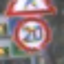

```python
from torchvision.transforms import Compose, ToTensor, Normalize, Resize, ToPILImage

# args are the new width and height
resize = Resize((128,128))
img = resize(image)
img.show()
```

You can combine transforms using `transforms.Compose`. You have a lot of options found in [torchvision.transforms.](https://pytorch.org/vision/stable/transforms.html)

Which transforms are we going to use for our task? In general, it is advised to use some data augmentation to help the model avoid overfitting.

In our case, to keep things simple (and fast) we just resize the image to a standard 32x32 and do some normalization, for the same reasons of the previous notebooks.

```python
# Our final transform will look like this
transform = Compose(
    [
    ToTensor(),
    Resize((32,32)),
    Normalize((0.5, 0.5, 0.5), (0.5, 0.5, 0.5))
    ])
```

What is `ToTensor()`? 🤔

Data in Pytorch is represented via `torch.tensor` objects. A tensor is just an N-dimensional matrix.

Whenever you want to manipulate some data or feed it to a neural network, you must transform it into a tensor first.

Operations on tensors are extremly fast (usually implemented in lower level c++) as they take full advantage of the available hardware.

```python
# tensors in torch are very similar to numpy's arrays


x = torch.tensor([[1,2],[3,4]])
print("A tensor of size", x.shape)
print(x)


x = torch.randn(3,4,4)
print("\n \nAnother tensor, of size", x.shape)
print(x)
```

```
A tensor of size torch.Size([2, 2])
tensor([[1, 2],
        [3, 4]])


Another tensor, of size torch.Size([3, 4, 4])
tensor([[[-0.1697, -0.8833,  1.3264, -0.1944],
         [ 0.5110, -1.1788, -0.6332, -0.3071],
         [-0.8988,  1.9528,  0.5253,  0.5158],
         [-0.3250, -0.2381, -0.5074,  0.1004]],

        [[ 0.2359, -0.1123,  2.1105, -0.6376],
         [-0.4124, -0.9989, -0.8763, -0.3348],
         [ 0.7839,  0.5030,  0.8850, -0.8063],
         [ 0.1604, -0.7288,  0.5635,  0.5469]],

        [[ 1.0165, -0.1015, -0.4101, -0.1132],
         [ 0.9815,  0.2316, -0.9357, -0.2975],
         [-1.3000,  0.5191,  0.4836,  0.4098],
         [-0.8442, -1.3010, -0.0055, -0.7659]]])
```

```python
#@title Exercise 🏋 : Compose transforms and show results

# Write a for loop that takes five random images of the dataset, applies a random transform, and shows the results before and after

resize = Resize ((123,123))
img = resize(image)
img.show()

normalize = Normalize((0.5, 0.5, 0.5))
```

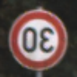

[figure not shown]

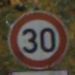

```python
#@title Peek 👀 solution

my_transform = Compose([torchvision.transforms.RandomHorizontalFlip(), Resize((128,128))])

for i in range(0,300,100):
  img = trainset[500+i][0]
  img.show()
  t_img = my_transform(img)
  t_img.show()
```

If you created a loop like:

```
for i in range(0,5):
  do stuff
```

you probably got all images of the same class. This is because the dataset is *sorted according to the class* and we did not **shuffle** it.

*Shuffling the dataset is crucial for the network to learn properly.* Training on sorted dataset can result in [catastrophic fortgetting](https://en.wikipedia.org/wiki/Catastrophic_interference#:~:text=Catastrophic%20interference%2C%20also%20known%20as,information%20upon%20learning%20new%20information.).

Luckily, the `torchvision.dataloader` will provide some features to shuffle our dataset.

### 1.3 Let's make the dataset smaller

We have **43 different classes** in this dataset ➡ we should train our model on 43 possible labels. Unfortunately, this would be too much for our poor (free) Colab GPU 😢.

Training models **requires good hardware** (usually GPUs or TPUs). The better the hardware, the faster you can train your neural network. If your model is too large, chances are it will not even fit your GPUs.

This is why often only big tech companies can afford to train big models, investing millions of dollars in the training process. 💸

```python
trainset = GTSRB(root='./data', split='train', download=True, transform=transform)
testset = GTSRB(root='./data', split='test', download=True, transform=transform)


labels_to_keep = {0,1,2,3}
keep_train_idx = [idx for idx, elem in enumerate(trainset) if elem[1] in labels_to_keep]
keep_test_idx = [idx for idx, elem in enumerate(testset) if elem[1] in labels_to_keep]

trainset = torch.utils.data.Subset(trainset, keep_train_idx)
testset = torch.utils.data.Subset(testset, keep_test_idx)
```

```python
len(trainset) #small enough
```

```
4110
```

### 1.4 Preprocessing and dataloaders

[`torch.utils.data.DataLoader`](https://pytorch.org/docs/stable/data.html?highlight=dataloader#torch.utils.data.DataLoader) is an iterator which provides:

- Data batching ➡ get samples from data in batches instead of one-by-one
- Data shuffling ➡ mix the data
- Parallel data loading using `multiprocessing` workers ➡ while the `GPU` is performing some computation on a batch, in parallel you can load the next batch.

Creating a dataloader from a dataset is straightforward, this is an example that highlights some of the most used parameters:

```python
batch_size = 4

trainloader = torch.utils.data.DataLoader(trainset, batch_size=batch_size,
                                          shuffle=True, num_workers=2)

testloader = torch.utils.data.DataLoader(testset, batch_size=batch_size,
                                         shuffle=False, num_workers=2)
```

```python
next(iter(trainloader))[0].shape
```

```
torch.Size([4, 3, 32, 32])
```

## 2. Training 🏃: Hands on ResNet-18

Let us have a look at how we can build and train a Neural Network.

### 2.1 Building blocks of Neural Networks

In Pytorch you can build your own neural networks with custom architectures by using the `nn.Module` class.

- You can combine different `nn.Module`s into your custom block, which should just implement the `forward` function.
- Pytorch will take care of the differentiation in the training process.
- A list of pre-implemented layers is found at [pytorch nn modules](https://pytorch.org/docs/stable/nn.html#convolution-layers)

A simple `nn.Linear` module performs a matrix multiplication:

[figure not shown]

```python
from torch.nn import Linear
import torch

# define a linear layer which accepts inputs of dimension 10 and produces outputs of dimension 100
linear_layer = Linear(in_features=10, out_features=100)

# random input batch with 30 samples
input_sample = torch.randn(30,10)

# this is calling the linear layer forward
output = linear_layer(input_sample)
output.shape
```

```
torch.Size([30, 100])
```

Unfortunately, we don't have time for implementing and training a decent Convolutional Neural Network here...

Good news though: Pytorch gives us the chance to download **pre-designed** and in some cases even **pre-trained** architectures.